# Analisis temporal de la expulsion de gases de efecto invernadero europeos

Emilio Coronado

2025-11-06

# Resumen

Este proyecto consiste en el estudio de las series temporales sobre un caso práctico. Se implementaran para ello diversos métodos estadísticos con el fin de crear modelos que se ajusten lo mejor posible a nuestro caso practico. Tales métodos como los modelos ARIMA nos permitirán modelar y predecir estos procesos estocásticos. Además de estas técnicas se utilizarán cartografías para la previsualización de estas series temporales.

## Obtención y tratamiento de los datos.

### Obtención de los datos a traves de la libreria de eurostat

Los datos utilizados para este estudio los obtenemos via eurostat. Este es el enlace: https://ec.europa.eu/eurostat/databrowser/view/env_ac_aigg_q/default/table?lang=en

```r
library(eurostat)
datos = get_eurostat("env_ac_aigg_q")
```

```
## Dataset query already saved in cache_list.json...
```

```
## Reading cache file C:\Users\emk\AppData\Local\Temp\RtmpaQAtzA/eurostat/6c1f659ce62d01cfc685172c15dfcbe6.rds
```

```
## Table  env_ac_aigg_q  read from cache file:  C:\Users\emk\AppData\Local\Temp\RtmpaQAtzA/eurostat/6c1f659ce62d01cfc685172c15dfcbe6.rds
```

```r
unique(datos$unit)
```

```
## [1] "PCH_SM" "THS_T"  "T_HAB"
```

### Depuración de los datos a través de la libreria dplyer

La principal variable de medición de interés es THS_T (Toneladas de gases de efecto invernadero expulsados).

```r
library(dplyr)
datosTT <- datos %>%
  filter(unit=="THS_T") %>%
  filter(geo!="EU27_2020")
```

Este primer filtrado de los datos se realiza para la posterior visualización y mapeo de los paises europeos.

## Mapeo y visualización de los datos.

### Obtención de las cartografias.

Para la creación de los mapas es necesario la descarga de una cartografía que contenga los paises de la Unión Europea y esto lo realizamos a través de la página de eurostat. Este es el enlace: https://ec.europa.eu/eurostat/web/gisco/geodata/reference-data/administrative-units-statistical-units/nuts

```r
library(sf)
library(tmap)
EU_MAP<-st_read("C:/EMILIO/UNIVERSIDAD/2022-2023/segundo cuatrimestre/TFG/NUTS_RG_60M_2021_3035.shp")
summary(EU_MAP)
```

```
##    NUTS_ID            LEVL_CODE      CNTR_CODE          NAME_LATN
##  Length:2010        Min.   :0.000   Length:2010        Length:2010
##  Class :character   1st Qu.:3.000   Class :character   Class :character
##  Mode  :character   Median :3.000   Mode  :character   Mode  :character
##                     Mean   :2.654
##                     3rd Qu.:3.000
##                     Max.   :3.000
##
##   NUTS_NAME           MOUNT_TYPE      URBN_TYPE       COAST_TYPE
##  Length:2010        Min.   :0.000   Min.   :0.000   Min.   :0.000
##  Class :character   1st Qu.:2.000   1st Qu.:1.000   1st Qu.:1.000
##  Mode  :character   Median :4.000   Median :2.000   Median :2.000
##                     Mean   :2.709   Mean   :1.536   Mean   :1.768
##                     3rd Qu.:4.000   3rd Qu.:2.000   3rd Qu.:3.000
##                     Max.   :4.000   Max.   :3.000   Max.   :3.000
##                     NA's   :1
##      FID                     geometry
##  Length:2010        MULTIPOLYGON :2010
##  Class :character   epsg:3035    :   0
##  Mode  :character   +proj=laea...:   0
##
##
##
##
```

```r
summary(EU_MAP$LEVL_CODE)
```

```
##    Min. 1st Qu.  Median    Mean 3rd Qu.    Max.
##   0.000   3.000   3.000   2.654   3.000   3.000
```

```r
st_crs(EU_MAP)
```

[output not shown]

Obtenemos el sistema de referencia que se utiliza en esta cartografía, así como los paises y sus repectivas islas ilustradas en el.

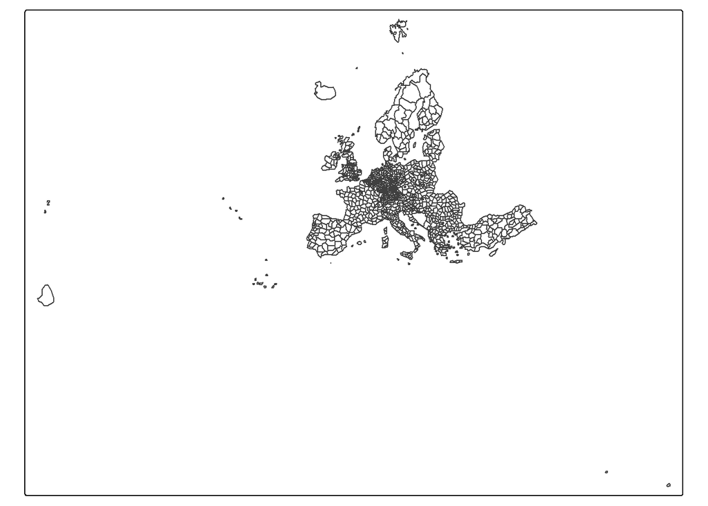

```r
tm_shape(EU_MAP)+
  tm_borders()
```

Las graficamos para visualizar y observamos como la cartografia contiene a parte de los paises todos los respectivos multipoligonos asociados a los pueblos y las comunidades autonomas.Por eso es necesario realizar un filtro en la cartografia y quedarnos solo con los NUTS=0 es decir los paises.

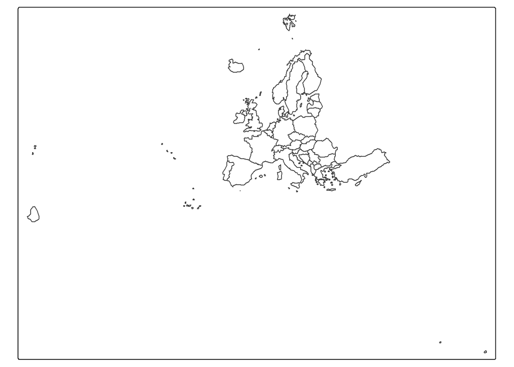

```r
EU_MAP <- EU_MAP %>%
    filter(LEVL_CODE==0)

tm_shape(EU_MAP)+
  tm_borders()
```

Una vez que nuestra cartografia se coresponde con nuestro objetivo de estudio es momento de unir los datos a la cartografia. Pero nuestra base de datos no contiene informacion de todos los paises pertenecientes a la cartografia por tanto habrá que unirlos solo para los que tenemos información.

### Unión con los datos.

```r
EU_mapa<-dplyr::left_join(EU_MAP, datosTT, by=c("NUTS_ID"="geo"))

EU_mapa <- EU_mapa %>%
  filter(values != "NA")
```

### Transformación del mapa para la visualización.

Filtramos un trimestre aleatorio para visualizar si todo esta en orden.

```r
EU_mapa2207 <- EU_mapa %>%
  filter(TIME_PERIOD=="2024-07-01")

tm_shape(EU_mapa2207,)+
  tm_fill(palette ="Blues",col = "values",style = "quantile")
```

```
## ── tmap v3 code detected ───────────────────────────────────────────────────────
```

[output not shown]

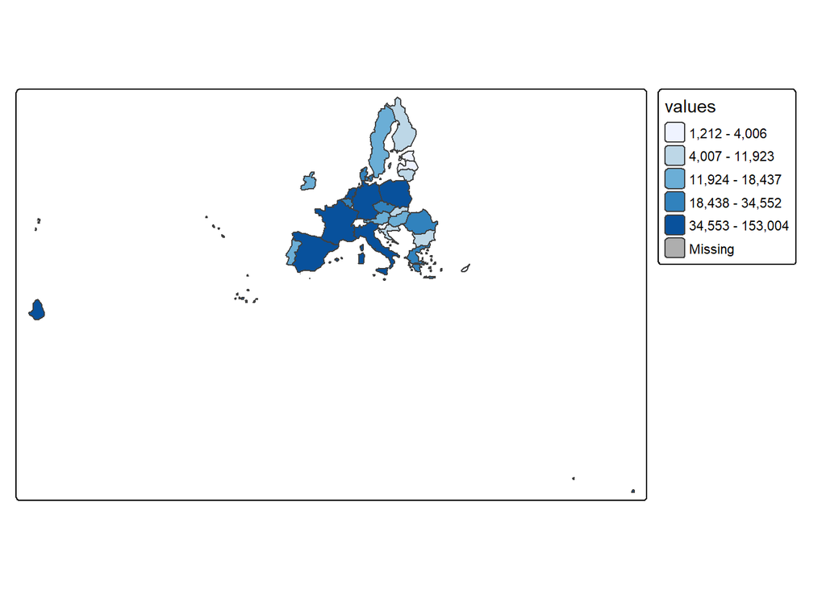

La cartografia por culpa de las islas de algunos paises queda muy alejada y la visualización no es buena, por lo que transformamos la caja para visualizar mejor.

Generamos una BBDD con las medias de los valores de cada pais a lo largo del tiempo para poder visualizar bien la importancia de cada país.

```r
EU_mapa_media <- EU_mapa %>%
    group_by(NUTS_NAME) %>%
    summarise(media_value = mean(values, na.rm = TRUE)) %>%
    ungroup()

#ahora visualizamos la importancia de cada país.
tmap_mode("view")
```

```
## ℹ tmap modes "plot" - "view"
## ℹ toggle with `tmap::ttm()`
```

```r
bbox_eu <- st_bbox(c(xmin = -20, ymin = 30, xmax = 40, ymax = 67), crs = 4326)


tm_shape(EU_mapa_media, bbox = bbox_eu) +
  tm_polygons(
    fill = "media_value",
    fill.scale = tm_scale(
      breaks = c(0, 14000, 36000, 68000, 92000, 150000, 280000),
      values = "brewer.yl_or_rd",  # antes: "YlOrRd"
      labels = c("≤ 14k", "14k – 36k", "36k – 68k", "68k – 92k", "92k - 150k",">150k")
    ),
    fill.legend = tm_legend(title = "Toneladas GEI expulsadas", outside = TRUE)
  ) +
  tm_view(view.zoom = 5) +
  tm_layout(frame = FALSE) +
  tm_title("Emisiones de Gases de Efecto Invernadero en media en Europa 2008-2024")
```

[interactive chart not shown]

Visualizamos como claramente Alemania es el país que más GEI expulsa, seguido por Francia, Italia y Polonia.

## Depuración de los datos y transformación a series temporales.

Para empezar vamos a filtrar nuestra base de datos y crear nuestros objetos en series temporales para su posterior analisis. Lo primero va a ser visualizar las gráficas para obtener información de su comportamiento.

```r
library(dplyr)
library(forecast)
```

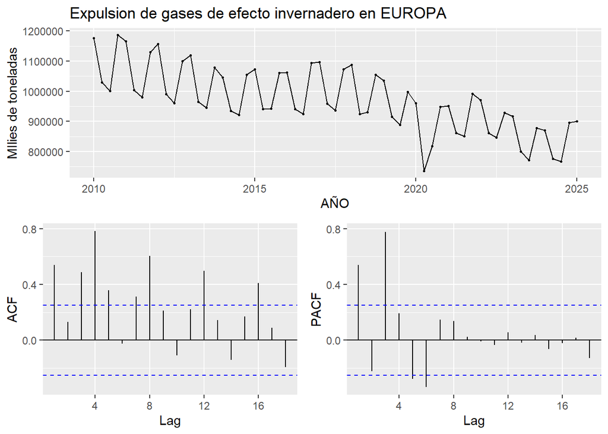

```r
library(ggplot2)
library(stats)

datosEU_THS_T <- datos %>%
  filter(unit=="THS_T") %>%
  filter(geo=="EU27_2020") %>%
  filter(nace_r2=="TOTAL_HH") %>%
  arrange(TIME_PERIOD)

datosEU_THS_T.ts <- ts(datosEU_THS_T$values,end=c(2025,1),frequency =4)


ggtsdisplay(datosEU_THS_T.ts,main="Expulsion de gases de efecto invernadero en EUROPA",xlab="AÑO",ylab="MIlies de toneladas")
```

```
## Ignoring unknown labels:
## • colour : "Gears"
```

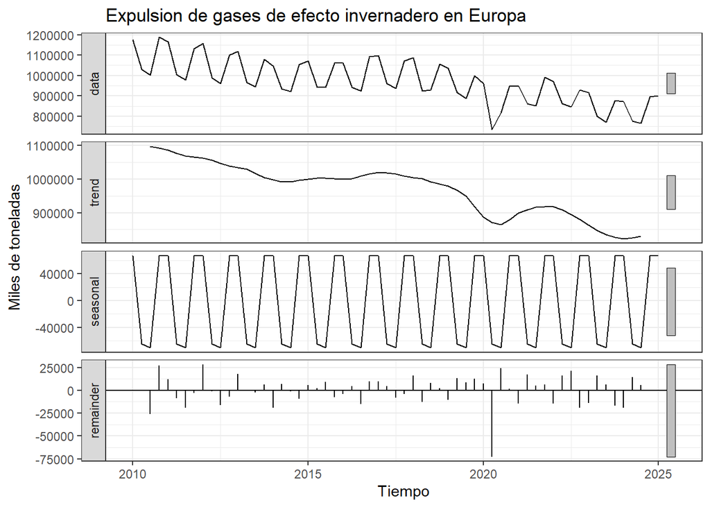

```r
fitTHS <- decompose(datosEU_THS_T.ts, type='additive')
autoplot(fitTHS)+
  labs(title = "Expulsion de gases de efecto invernadero en Europa",
       x = "Tiempo",
       y = "Miles de toneladas",
       colour = "Gears")+
    theme_bw()
```

Se observa una estacionalidad trimestral super clara a parte de una tendencia decreciente a lo largo de toda la serie salvo por el momento del efecto inverso del covid. También observamos una falta de estacionariedad clara y por tanto ni nos fijamos en los coeficientes de autocorrelación.

Creamos otra grafica para visualizar Mejor:

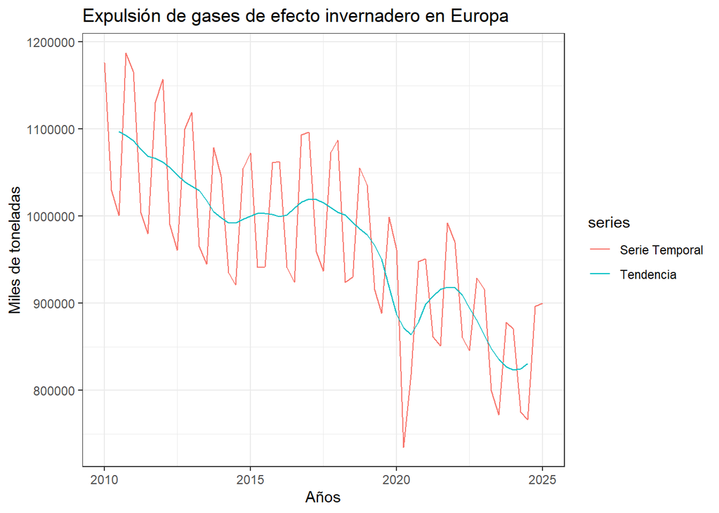

```r
autoplot(datosEU_THS_T.ts, series="Serie Temporal") +
    autolayer(trendcycle(fitTHS), series="Tendencia") +
    labs(title = "Expulsión de gases de efecto invernadero en Europa",
       x = "Años",
       y = "Miles de toneladas"
       ) +
    theme_bw()
```

Una vez visualizado la tendencia de forma mas grafica pasamos a intentar entender mejor la estacionaidad de nuestra serie.

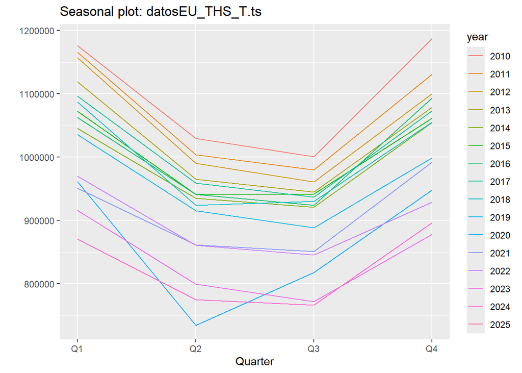

```r
ggseasonplot(datosEU_THS_T.ts)
```

```r
summary(datosEU_THS_T$values)
```

```
##    Min. 1st Qu.  Median    Mean 3rd Qu.    Max.
##  734660  915330  958964  970101 1054939 1187357
```

Y como podemos observar, hay una clara estacionalidad. En los segundos y terceros trimestres del año los europeos expulsamos menos gases de efecto invernadero que en el primer y cuarto trimestre. Lo más probable debido a las temperaturas bajas de esos momentos(otoño/invierno) y el uso de energías contaminantes para la generación de calor.

## Metodologia Box_Jenkins

### Primera Etapa:Estacionarización de las series.

Como habiamos dicho anteriormente se ha observado claramente falta de estacionariedad y por tanto tendremos que estabilizar la serie y desestacionalizarla.

#### Diferenciaciones.

Pasamos a probar cuantas diferenciaciones serán necesarias para estabilizar las series.

```r
ndiffs(datosEU_THS_T.ts)#regulares
```

```
## [1] 1
```

```r
nsdiffs(datosEU_THS_T.ts)#estacionales
```

```
## [1] 1
```

Por tanto va a ser necesario realizar una diferencia regular y una estacional para estacionarizar las dos series temporales del estudio.

##### Diferenciación Regular

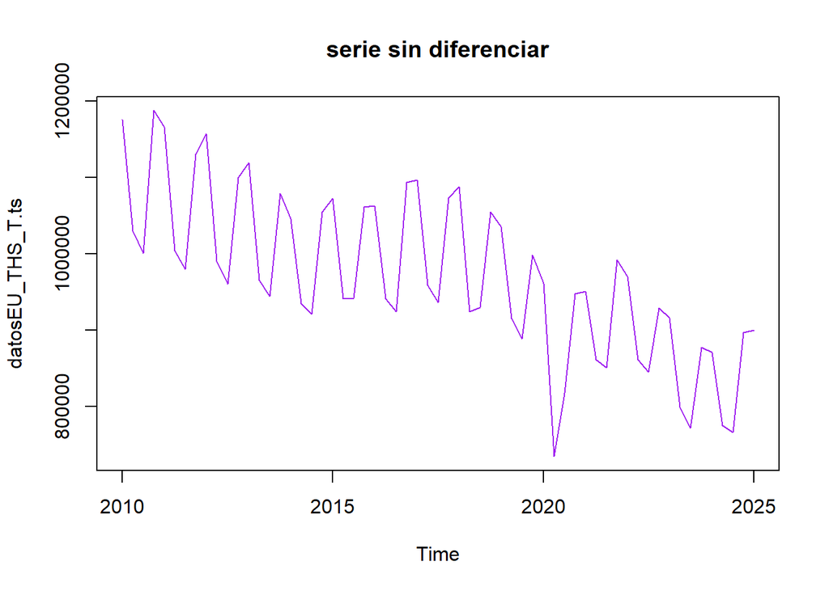

```r
library(forecast)
diff.datosEU_THS_T.ts<-diff(datosEU_THS_T.ts)
plot(datosEU_THS_T.ts,main="serie sin diferenciar",col="purple")
```

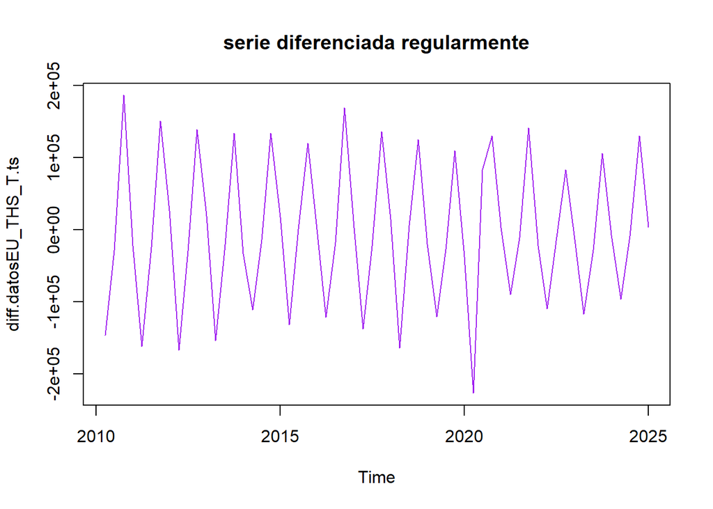

```r
plot(diff.datosEU_THS_T.ts,main="serie diferenciada regularmente",col="purple")
```

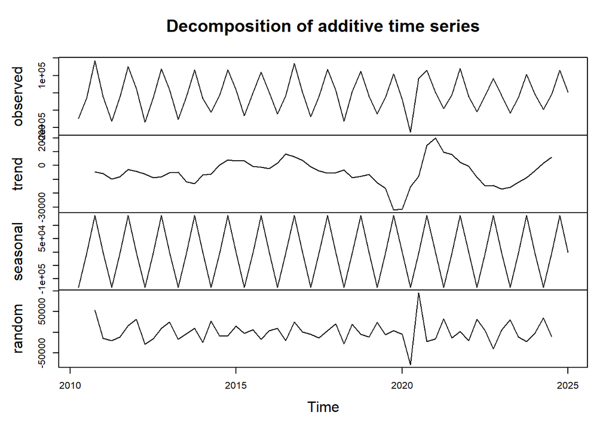

```r
plot(decompose(diff.datosEU_THS_T.ts))
```

Ahora observamos como las series se han estabilizado en media, pero siguen conteniendo la parte estacional y aleatoria del modelo, por ello tenemos que diferenciar estacionalmente.

##### Diferenciación estacional

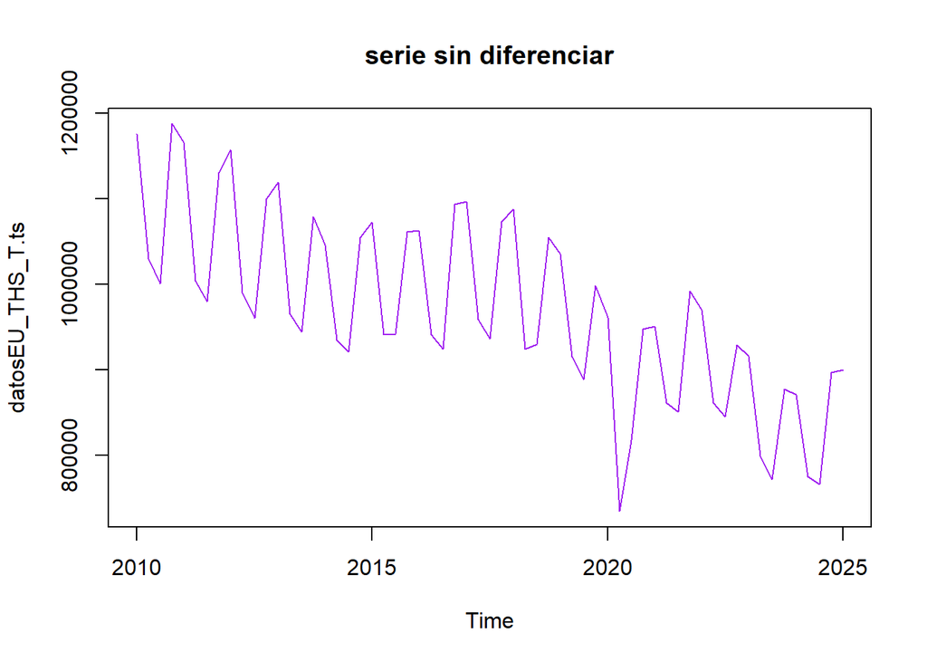

```r
diff.datosEU_THS_T.ts.4<-diff(diff.datosEU_THS_T.ts, lag = 4)
plot(datosEU_THS_T.ts,main="serie sin diferenciar",col="purple")
```

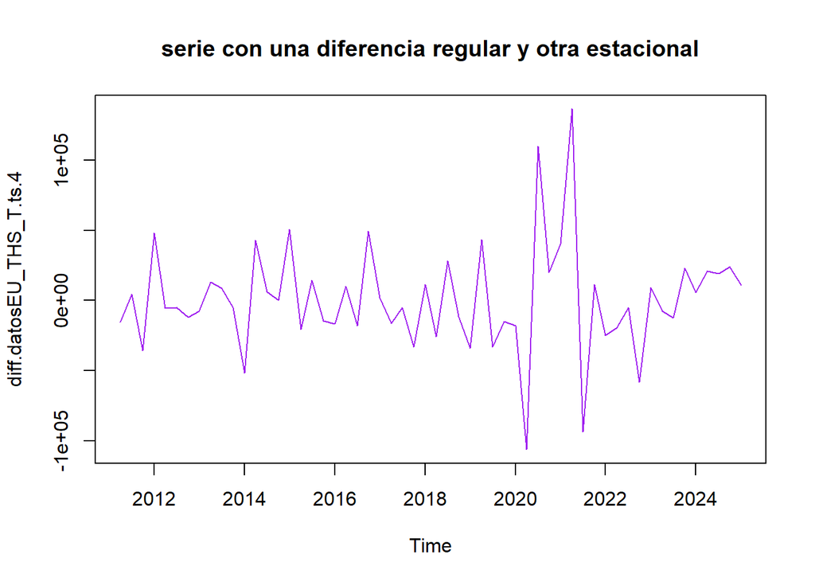

```r
plot(diff.datosEU_THS_T.ts.4,main="serie con una diferencia regular y otra estacional",col="purple")
```

No observamos heterocedasticidad y por tanto no va a ser necesaria hacer ninguna transformación logaritmica o de box-cox. A parte podemos confirmar como se ha eliminado la estacionalidad de la serie y por tanto podemos pasar a intentar visualizar las autocorrelaciones del modelo estacionario para que nos de una idea de que modelo ARIMA nos permitirá modelar dicha serie.

Una vez supuesta la hipótesis de estacionariedad hay que comprobarla y eso lo relizamos a traves del contraste dickey fuller aumentado.

##### Contraste de Estacionariedad

```r
library(tseries)
adf<-adf.test(diff.datosEU_THS_T.ts.4)
adf$p.value
```

```
## [1] 0.01
```

#### Visualización de las Autocorrelaciones.

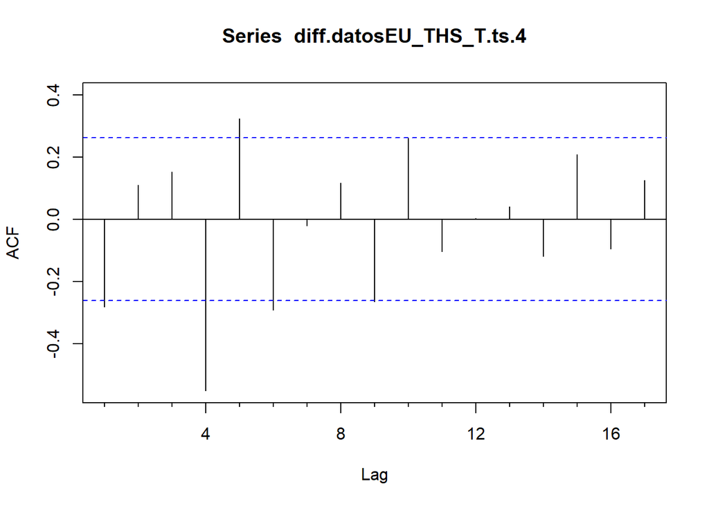

```r
Acf(diff.datosEU_THS_T.ts.4)
```

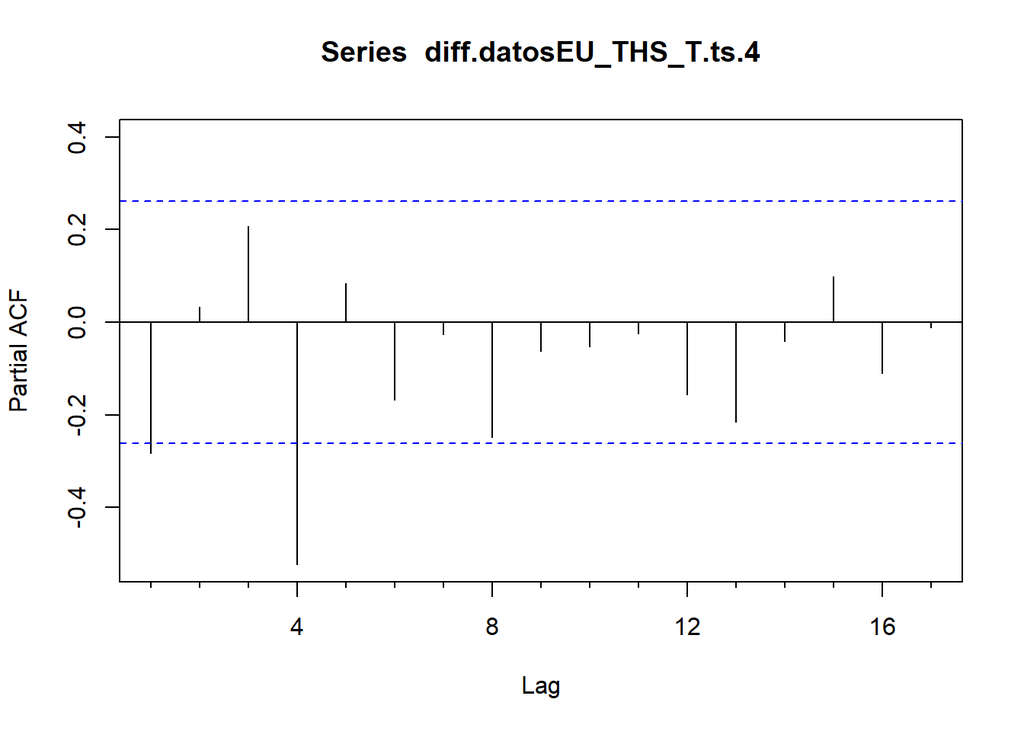

```r
Pacf(diff.datosEU_THS_T.ts.4)
```

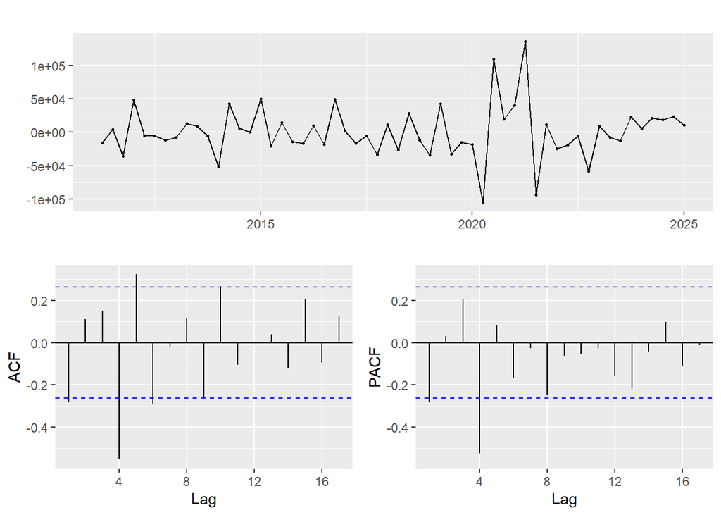

```r
ggtsdisplay(diff.datosEU_THS_T.ts.4)
```

Observamos como decrece rapidamente la funcion de autocorrelacion simple y que en la función de autocorelacion parcial sobresale el primer y cuarto autorregresor, por tanto el modelo ARIMA puede que necesite un paremetro p=1 o 4 a parte de alguna diferenciación y por tanto su parametro d puede que tome el valor de la unidad también.

### Segunda Etapa:Modelización de las series.

#### Detección de los modelos ARIMA

Una vez que hayamos conseguido que la serie sea estacionaria para obtener información de sus autocorrelaciones es hora de identificicar los posibles modelos que mejor se ajusten a nuestra serie original. Para ello probamos distintos modelos ARIMA para a posteriori decidir cual nos convence mas a través de los estadísticos Akaike y BIC.

```r
library(forecast)
arima1<- Arima(datosEU_THS_T.ts, order=c(0,1,2), seasonal=list(order=c(0,1,1),period=4))
arima2<- Arima(datosEU_THS_T.ts, order=c(1,1,0), seasonal=list(order=c(1,1,1),period=4))
arima3<- Arima(datosEU_THS_T.ts, order=c(1,1,1), seasonal=list(order=c(1,1,0),period=4))
arima4<- Arima(datosEU_THS_T.ts, order=c(1,1,1), seasonal=list(order=c(1,1,1),period=4))
arima5<- Arima(datosEU_THS_T.ts, order=c(1,1,2), seasonal=list(order=c(1,1,1),period=4))
arima6<- Arima(datosEU_THS_T.ts, order=c(0,1,1), seasonal=list(order=c(0,1,1),period=4))
arima7<- Arima(datosEU_THS_T.ts, order=c(1,1,0), seasonal=list(order=c(1,1,0),period=4))
arima8<- Arima(datosEU_THS_T.ts, order=c(1,0,0), seasonal=list(order=c(0,1,1),period=4))
arima9<- Arima(datosEU_THS_T.ts, order=c(0,1,0), seasonal=list(order=c(0,1,1),period=4))
```

#### Elección del modelo a través de los estadisticos.

```r
#Para la serie de miles de toneladas
AIC(arima1,arima2,arima3,arima4,arima5,arima6,arima7,arima8,arima9)
```

```
##        df      AIC
## arima1  4 1317.362
## arima2  4 1318.073
## arima3  4 1327.749
## arima4  5 1317.122
## arima5  6 1318.990
## arima6  3 1315.776
## arima7  3 1325.758
## arima8  3 1339.630
## arima9  2 1316.630
```

```r
BIC(arima1,arima2,arima3,arima4,arima5,arima6,arima7,arima8,arima9)
```

```
##        df      BIC
## arima1  4 1325.464
## arima2  4 1326.175
## arima3  4 1335.850
## arima4  5 1327.249
## arima5  6 1331.142
## arima6  3 1321.852
## arima7  3 1331.834
## arima8  3 1345.759
## arima9  2 1320.681
```

Según el estadístico akaike el modelo que minimiza la perdida de informacíon sería el arima6 y luego el arima9;

ARIMA6 (p=0,d=1,q=1)(P=0,D=1,Q=1)4

ARIMA9 (p=0,d=1,q=0)(P=0,D=1,Q=1)4

#### Diagnosis del modelo a través de los residuos.

visualizamos los errores de los modelos para luego contrstar la normalidad de estos:

En modelos ARIMA para series macroeconómicas o ambientales, la normalidad perfecta de residuos rara vez se cumple.

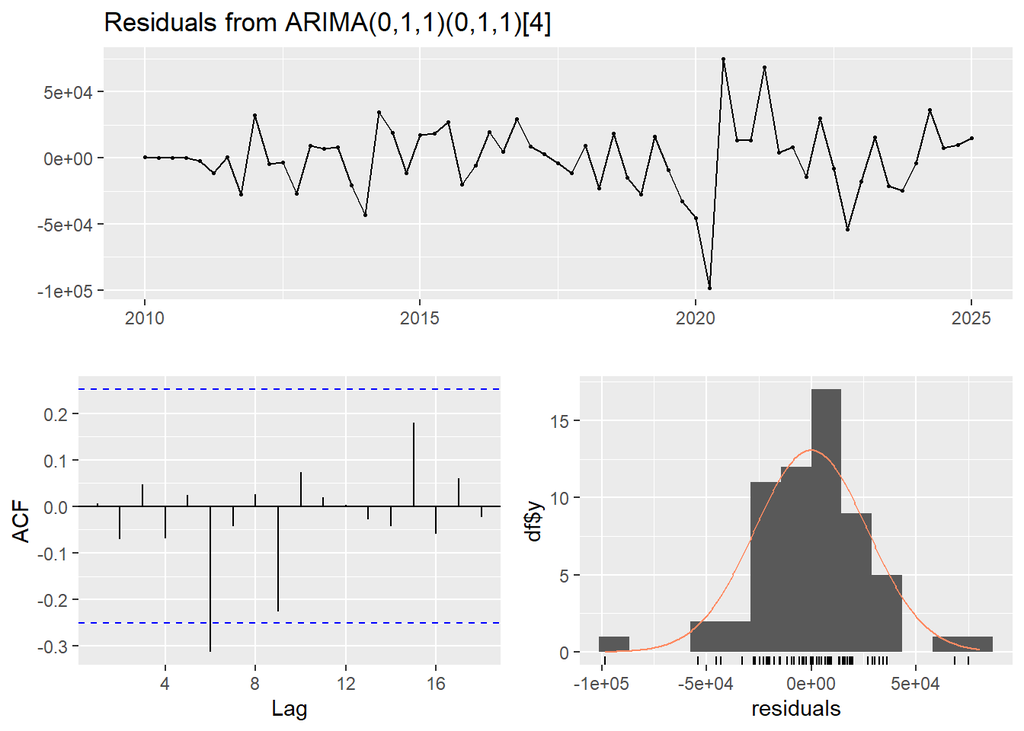

```
##
##  Ljung-Box test
##
## data:  Residuals from ARIMA(0,1,1)(0,1,1)[4]
## Q* = 7.8306, df = 6, p-value = 0.2508
##
## Model df: 2.   Total lags used: 8
```

```r
checkresiduals(arima6)
```

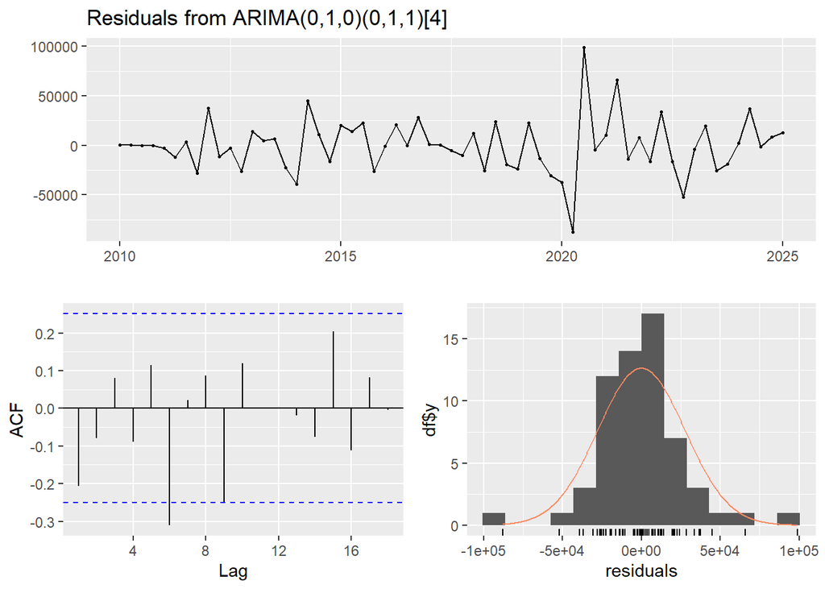

```
##
##  Ljung-Box test
##
## data:  Residuals from ARIMA(0,1,0)(0,1,1)[4]
## Q* = 12.363, df = 7, p-value = 0.08922
##
## Model df: 1.   Total lags used: 8
```

```r
checkresiduals(arima9)
```

Ahora pasamos a ver si los parametros de nuestros modelos son significativos.

```r
library(lmtest)
coeftest(arima6) #el parámetro de media movil etsacional sale significativo.
```

```
##
## z test of coefficients:
##
##      Estimate Std. Error z value  Pr(>|z|)
## ma1  -0.24465    0.13965 -1.7519   0.07978 .
## sma1 -0.81723    0.11101 -7.3618 1.814e-13 ***
## ---
## Signif. codes:  0 '***' 0.001 '**' 0.01 '*' 0.05 '.' 0.1 ' ' 1
```

```r
Box.test(arima6$residuals, lag = 20, type = "Ljung-Box")
```

```
##
##  Box-Ljung test
##
## data:  arima6$residuals
## X-squared = 17.535, df = 20, p-value = 0.618
```

Como el p-valore(0.618) supera al nivel de significación 0.05, afirmamos la hipótesis nula y por tanto confirmamos que los residuos estan incorrelados. De tal manera ahora tenemos nuestro modelo comprobado y podemos pasar a predecir con el.

### Tercera etapa: Predicción.

```r
library(forecast)
library(dygraphs)

# Escalar a millones de toneladas
serie_mill <- datosEU_THS_T.ts / 1e6

# Forecast y escala
prediccionesTHS <- forecast(arima6, level = 95, h = 10)
pred_mill <- prediccionesTHS$mean / 1e6

dygraph(
  cbind(Serie = serie_mill, Predicción = pred_mill),
  main = "GEI expulsados por la UE"
) %>%
  dySeries("Serie", label = "Histórico", strokeWidth = 2) %>%
  dySeries("Predicción", label = "Pronóstico", strokeWidth = 3, strokePattern = "dashed") %>%
  dyAxis("y", label = "Millones de toneladas") %>%
  dyAxis("x", label = "Año") %>%
  dyOptions(
    drawGrid = TRUE,
    useDataTimezone = FALSE,
    fillGraph = FALSE,
    strokeWidth = 2,
    titleHeight = 40
  ) %>%
  dyLegend(show = "always") %>%
  dyHighlight(
    highlightCircleSize = 5,
    highlightSeriesBackgroundAlpha = 0.25,
    hideOnMouseOut = FALSE
  ) %>%
  dyRangeSelector(height = 30)
```

[interactive chart not shown]

Ahora voy a graficar los datos de una forma que pueda comparar los trimestres de cada año de una forma clara y visual.

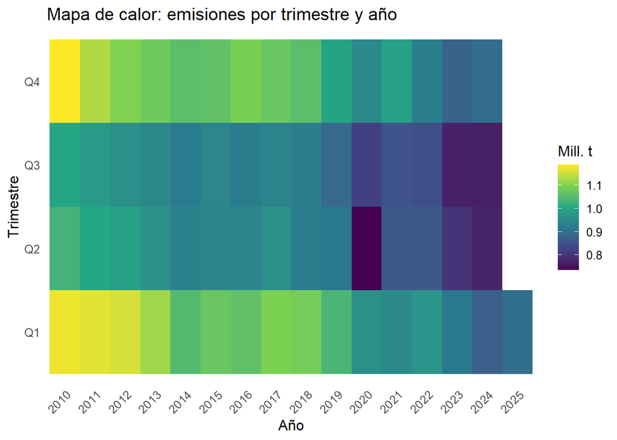

```r
library(dplyr)
library(ggplot2)
library(zoo)     # para yearqtr
library(scales)  # para etiquetas bonitas

# Escala a millones
serie_mill <- as.numeric(datosEU_THS_T.ts) / 1e6 #Así las unidades están en millones de toneladas
ti <- as.yearqtr(time(datosEU_THS_T.ts)) #Formato de cuartos de año para poder visualizar bien

df_q <- tibble::tibble(
  Year    = as.integer(format(ti, "%Y")),
  Quarter = factor(format(ti, "Q%q"), levels = c("Q1","Q2","Q3","Q4")),
  Value   = serie_mill
)

ggplot(df_q, aes(x = factor(Year), y = Quarter, fill = Value)) +
  geom_tile() +
  scale_fill_viridis_c(name = "Mill. t") +
  labs(title = "Mapa de calor: emisiones por trimestre y año",
       x = "Año", y = "Trimestre") +
  theme_minimal(base_size = 12) +
  theme(panel.grid = element_blank(),
        axis.text.x = element_text(angle = 45, hjust = 1))
```

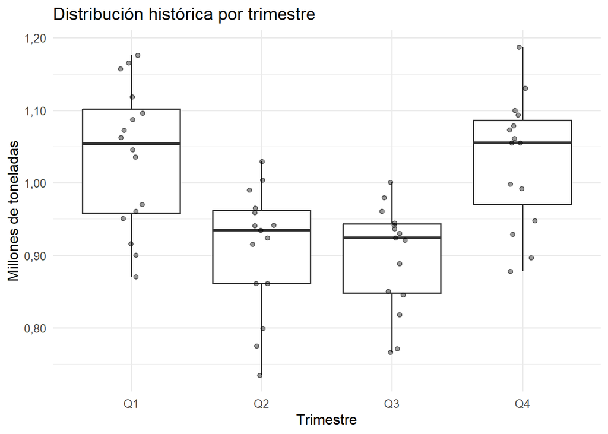

```r
ggplot(df_q, aes(x = Quarter, y = Value)) +
  geom_boxplot(outlier.alpha = 0.3) +
  geom_jitter(width = 0.1, alpha = 0.4) +
  scale_y_continuous(labels = label_number(big.mark = ".", decimal.mark = ",")) +
  labs(title = "Distribución histórica por trimestre",
       x = "Trimestre", y = "Millones de toneladas") +
  theme_minimal(base_size = 12)
```

En el mapa de calor y en este gráfico boxplot segmentado por trimestres se aprecia muy bien la estacionalidad de los datos.

```r
library(forecast)
library(dplyr)
library(tidyr)
library(zoo)
library(DT)

# --- 1) Serie y forecast en millones ---
serie_mill <- as.numeric(datosEU_THS_T.ts) / 1e6
pred <- forecast(arima6, h = 10)
pred_mill <- as.numeric(pred$mean) / 1e6

# --- 2) Índices de tiempo correctos (trimestral) ---
ti_hist <- as.yearqtr(time(datosEU_THS_T.ts))
ti_pred <- as.yearqtr(time(pred$mean))

df_hist <- tibble(
  Year    = as.integer(format(ti_hist, "%Y")),
  Quarter = factor(format(ti_hist, "Q%q"), levels = c("Q1","Q2","Q3","Q4")),
  Value   = serie_mill,
  Pred    = FALSE
)

df_pred <- tibble(
  Year    = as.integer(format(ti_pred, "%Y")),
  Quarter = factor(format(ti_pred, "Q%q"), levels = c("Q1","Q2","Q3","Q4")),
  Value   = pred_mill,
  Pred    = TRUE
)

df <- bind_rows(df_hist, df_pred) %>%
  arrange(Year, Quarter)

# --- 3) Pasar a formato ancho (años x trimestres) ---
value_wide <- df %>%
  select(Year, Quarter, Value) %>%
  pivot_wider(names_from = Quarter, values_from = Value) %>%
  arrange(Year)

flag_wide <- df %>%
  select(Year, Quarter, Pred) %>%
  pivot_wider(names_from = Quarter, values_from = Pred) %>%
  arrange(Year) %>%
  rename(Q1_pred = Q1, Q2_pred = Q2, Q3_pred = Q3, Q4_pred = Q4)

tabla <- value_wide %>%
  left_join(flag_wide, by = "Year")

# --- 4) Tabla interactiva con predicciones coloreadas ---
DT::datatable(
  tabla,
  rownames = FALSE,
  caption = "Emisiones por año y trimestre (millones de toneladas). Las celdas coloreadas son predicciones.",
  options = list(
    pageLength = 50,
    dom = "tip",
    columnDefs = list(
      # Ocultar columnas auxiliares de predicción
      list(visible = FALSE,
           targets = which(names(tabla) %in% c("Q1_pred","Q2_pred","Q3_pred","Q4_pred")) - 1)
    )
  )
) %>%
  formatRound(c("Q1","Q2","Q3","Q4"), 2) %>%
  # Colorear las predicciones usando las columnas *_pred ocultas
  formatStyle('Q1', backgroundColor = styleEqual(c(TRUE, FALSE), c("#e3f2fd", "white")),
              valueColumns = "Q1_pred") %>%
  formatStyle('Q2', backgroundColor = styleEqual(c(TRUE, FALSE), c("#e3f2fd", "white")),
              valueColumns = "Q2_pred") %>%
  formatStyle('Q3', backgroundColor = styleEqual(c(TRUE, FALSE), c("#e3f2fd", "white")),
              valueColumns = "Q3_pred") %>%
  formatStyle('Q4', backgroundColor = styleEqual(c(TRUE, FALSE), c("#e3f2fd", "white")),
              valueColumns = "Q4_pred")
```

| Year | Q1 | Q2 | Q3 | Q4 | Q1_pred | Q2_pred | Q3_pred | Q4_pred |
| --- | --- | --- | --- | --- | --- | --- | --- | --- |
| 2010 | 1.17590239 | 1.029454973 | 1.00070847 | 1.187357218 | False | False | False | False |
| 2011 | 1.165620153 | 1.00379981 | 0.979639544 | 1.130471079 | False | False | False | False |
| 2012 | 1.157112922 | 0.990020445 | 0.960792764 | 1.099878248 | False | False | False | False |
| 2013 | 1.118829637 | 0.965008329 | 0.94467027 | 1.078583788 | False | False | False | False |
| 2014 | 1.045669549 | 0.934741519 | 0.920702125 | 1.054792715 | False | False | False | False |
| 2015 | 1.07255151 | 0.941090579 | 0.941650759 | 1.061383213 | False | False | False | False |
| 2016 | 1.062460096 | 0.941333625 | 0.9239332219999999 | 1.093355492 | False | False | False | False |
| 2017 | 1.096460516 | 0.9589636629999999 | 0.9365315790000001 | 1.072870715 | False | False | False | False |
| 2018 | 1.087410726 | 0.9239754259999999 | 0.930034569 | 1.054938545 | False | False | False | False |
| 2019 | 1.035496888 | 0.915330143 | 0.8884914939999999 | 0.998502007 | False | False | False | False |

[output cut: 8 more lines]

El análisis realizado permite caracterizar con precisión la evolución reciente de las emisiones de gases de efecto invernadero en Europa y ofrecer una proyección sólida a corto y medio plazo. Tras el ajuste y validación del modelo SARIMA(0,1,1)(0,1,1)[4], los resultados muestran una continuidad en la tendencia descendente observada durante la última década, marcada tanto por mejoras tecnológicas como por políticas climáticas más estrictas.

Las previsiones a partir del segundo trimestre de 2025 indican que las emisiones seguirán reduciéndose de forma moderada y estable. En términos intertrimestrales, se espera que los valores permanezcan dentro de rangos similares a los actuales, mientras que la evolución interanual anticipa disminuciones progresivas y consistentes. Por ejemplo, los niveles estimados para 2026 y 2027 continúan situándose por debajo de los registrados en 2024 y 2025, consolidando una trayectoria de descenso estructural.

El patrón estacional —con mínimos habituales en los trimestres centrales del año y repuntes suaves en invierno— se mantiene, pero en todos los casos con valores más bajos respecto a años anteriores. Esto sugiere que el proceso de descarbonización europeo no solo continúa, sino que se profundiza.

En conjunto, el análisis confirma que Europa avanza hacia una reducción sostenida de sus emisiones, sin indicios de incrementos significativos a corto plazo. Las previsiones reforzan la conclusión de que las medidas implementadas están teniendo un efecto apreciable, y que, salvo perturbaciones externas importantes, la tendencia decreciente se mantendrá más allá de 2027.